# Take-home Exercise 2

In this take home exercise I will explore the take home exercise 1 of my classmate [Shachi Anirudha Raodeo](https://visualanalytics.netlify.app/th_ex/th_ex1.html).

Heranshan Subramaniam https://www.linkedin.com/in/heranshan/ (School of Computing and Information Systems)https://scis.smu.edu.sg/  
2022-05-01

# Overview

In this take-home exercise, I will:

- Select one of the Take-home Exercise 1 prepared by my classmate,
- Critic the submission in terms of clarity and aesthetics, and
- Remake the original design by using the data visualization principles and best practice learnt in Lesson 1 and 2.

# Getting Started

The required packages will be called with the following code chunk:

```r
packages = c('tidyverse','ggplot2', 'ggpubr')
for (p in packages){
  if(!require(p, character.only = T)){
    install.packages(p)
  }
  library(p, character.only = T)
}
```

# Importing Data

```r
participants_data <- read_csv("data/Participants.csv")
```

# Data Preperation

Rebuild data frame as done by Yanmu.

```r
participants_data$age <- as.factor(participants_data$age)
levels(participants_data$age)
```

```
 [1] "18" "19" "20" "21" "22" "23" "24" "25" "26" "27" "28" "29" "30"
[14] "31" "32" "33" "34" "35" "36" "37" "38" "39" "40" "41" "42" "43"
[27] "44" "45" "46" "47" "48" "49" "50" "51" "52" "53" "54" "55" "56"
[40] "57" "58" "59" "60"
```

```r
one <- c("18", "19", "20")
two <- c("21", "22", "23", "24", "25", "26", "27", "28", "29", "30" )
three <- c("31", "32", "33", "34", "35", "36", "37", "38", "39", "40")
four <- c( "41", "42", "43", "44", "45", "46", "47", "48", "49", "50")
five <-  c( "51", "52", "53", "54", "55", "56", "57", "58", "59", "60")


participants_data_mod <- participants_data %>%
  mutate(age_modified = case_when(
    age %in% one ~ "<=20",
    age %in% two ~ "20's",
    age %in% three ~ "30's",
    age %in% four ~ "40's",
    age %in% five ~ "50+")) %>%
  select(-age)

participants_data_mod[order(participants_data_mod$age_modified), ]
```

```
# A tibble: 1,011 x 7
   participantId householdSize haveKids educationLevel   interestGroup
           <dbl>         <dbl> <lgl>    <chr>            <chr>
 1             8             3 TRUE     Bachelors        G
 2            13             3 TRUE     Bachelors        J
 3            18             3 TRUE     Graduate         I
 4            29             3 TRUE     Low              C
 5            35             3 TRUE     Low              J
 6            53             3 TRUE     Low              H
 7            67             3 TRUE     HighSchoolOrCol~ C
 8            77             2 FALSE    HighSchoolOrCol~ C
 9            88             2 FALSE    HighSchoolOrCol~ A
10            90             2 FALSE    HighSchoolOrCol~ E
# ... with 1,001 more rows, and 2 more variables: joviality <dbl>,
#   age_modified <chr>
```

# Data Visualization and Insights

## Graph 1: Distribution of Joviality

### Original Graph

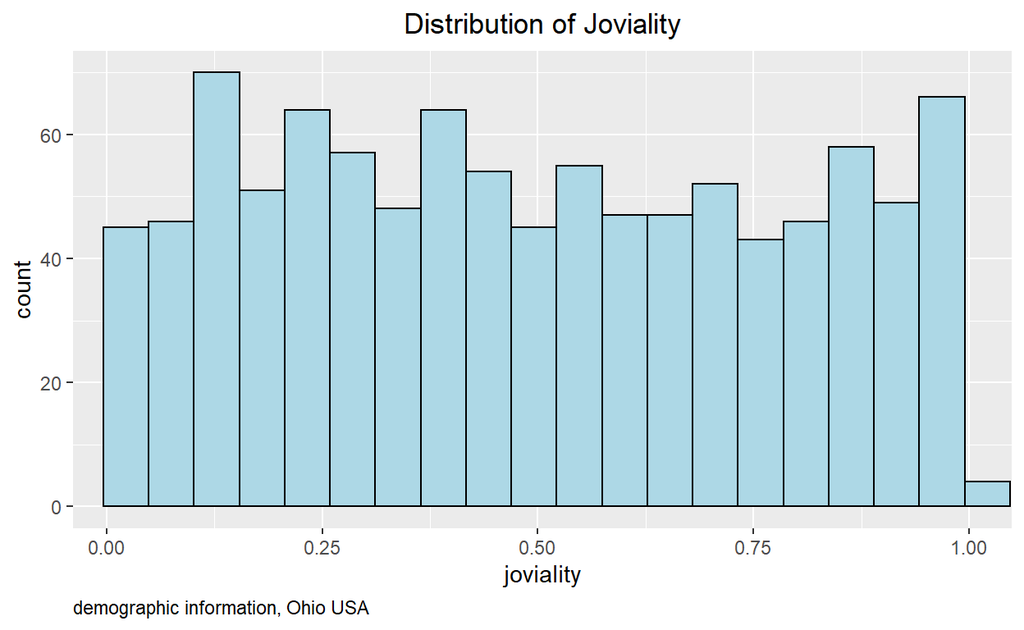

```r
ggplot(data=participants_data,
aes(x = joviality)) +
geom_histogram(bins=20,
boundary = 50,
color="black",
fill="light blue") +
coord_cartesian(xlim=c(0.01,1)) +
labs(
    title = "Distribution of Joviality",
    caption = "demographic information, Ohio USA"
  ) +
  theme(
    plot.title = element_text(hjust = 0.5),
    plot.subtitle = element_text(hjust = 1),
    plot.caption = element_text(hjust = 0)
  )
```

### Comments

Pros:

1. Graph is clear and aesthetically pleasing
2. Graph has understandable title and axis labels
3. Appropirate bin size selected

Possible areas for improvement:

1. Y axis can be placed horizontally to enhance readability
2. Axis can be renamed to title case, instead of using data frame column header
3. Additional statistic could be added to provide reader with more information

### Revised Graph

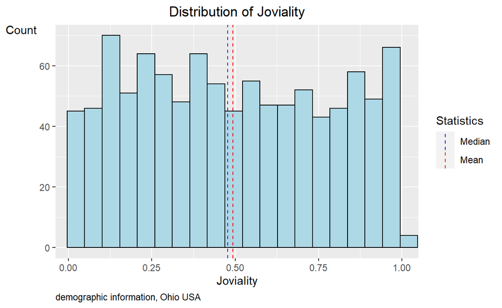

```r
joviality_stat <- participants_data %>%
  summarize(j_median = median(joviality),
            j_mean = mean(joviality))

ggplot(data=participants_data,
aes(x = joviality)) +
geom_histogram(bins=20,
boundary = 50,
color="black",
fill="light blue") +
  geom_vline(data= joviality_stat,
             aes(xintercept = j_median, color= 'Median'),
             linetype= 'dashed',
             size= .4) +
  geom_vline(data= joviality_stat,
             aes(xintercept = j_mean, color= 'Mean'),
             linetype= 'dashed',
             size= .4) +
  scale_color_manual(name= 'Statistics',
                     values = c(Median= 'Blue', Mean= 'Red')) +
coord_cartesian(xlim=c(0.01,1)) +
labs(x = "Joviality", y = "Count",
    title = "Distribution of Joviality",
    caption = "demographic information, Ohio USA"
  ) +
  theme(
    axis.title.y= element_text(angle=0),
    plot.title = element_text(hjust = 0.5),
    plot.subtitle = element_text(hjust = 1),
    plot.caption = element_text(hjust = 0)
  )
```

## Graph 2: Distribution of Age for Different Household Types

### Original Graph

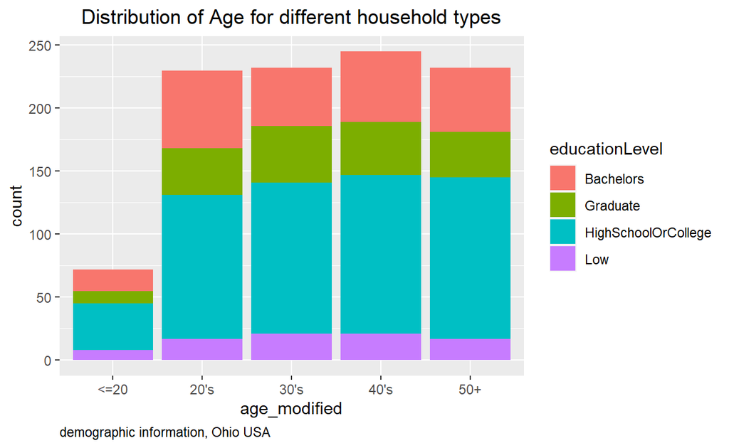

```r
ggplot(data=participants_data_mod,
       aes(x=age_modified, fill = educationLevel)) +
geom_bar()+
labs(
    title = "Distribution of Age for different household types",
    caption = "demographic information, Ohio USA"
  ) +
  theme(
    plot.title = element_text(hjust = 0.5),
    plot.subtitle = element_text(hjust = 1),
    plot.caption = element_text(hjust = 0)
  )
```

### Comments

Pros:

1. Graph has understandable title and axis labels

Cons:

1. Y axis can be placed horizontally to enhance readability
2. Axis and legend title can be renamed to title case, instead of using data frame column header
3. Graph is too cluttered with information, making it difficult for reader to interpret. Graph data can be better represented by 2 different graphs.
4. x ticker can be removed
5. Statistical data can be added to the bar chart to make it clearer.

### Revised Graphs

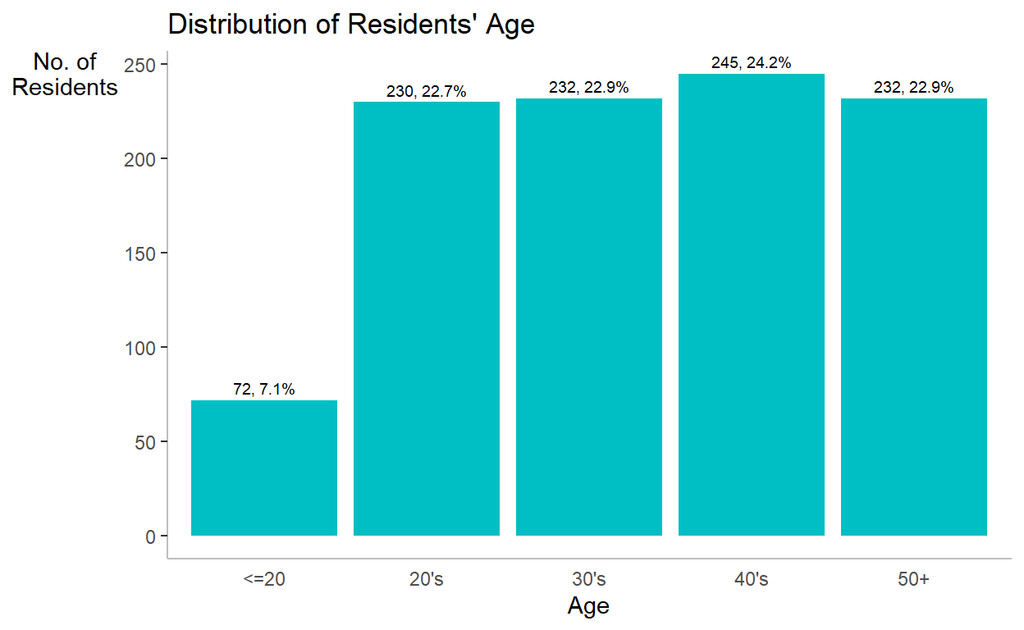

```r
ggplot(data= participants_data_mod,
       aes(x= age_modified)) +
  geom_bar(fill= "#00BFC4") +
  geom_text(stat = 'count',
           aes(label= paste0(stat(count), ', ',
                             round(stat(count)/sum(stat(count))*100,
                             1), '%')), vjust= -0.5, size= 2.5) +
  labs(y= 'No. of\nResidents', x= 'Age',
       title = "Distribution of Residents' Age") +
  theme(axis.title.y= element_text(angle=0), axis.ticks.x= element_blank(),
        panel.background= element_blank(), axis.line= element_line(color= 'grey'))
```

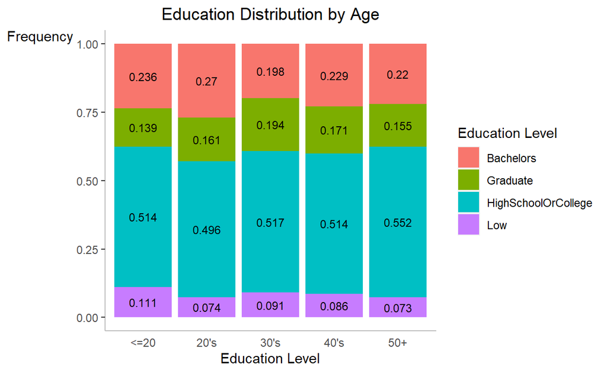

```r
participants_data_mod %>%
  group_by(age_modified, educationLevel) %>%
  summarise(n = n()) %>%
  mutate(freq = round(n / sum(n),3)) %>%
  ggplot(aes(x=age_modified, y=freq, fill = educationLevel)) +
   geom_col() +
    geom_text(aes(label = freq), size = 3, position = position_stack(vjust = 0.5)) +
    labs(x="Education Level", y="Frequency",
         title = "Education Distribution by Age", fill = "Education Level") +
    theme(
    axis.title.y= element_text(angle=0), axis.ticks.x= element_blank(),
    plot.title = element_text(hjust = 0.5),
    plot.subtitle = element_text(hjust = 1),
    plot.caption = element_text(hjust = 0),
    panel.background= element_blank(), axis.line= element_line(color= 'grey')
  )
```

## Graph 3: Joviality Measure by Age and Education Level

### Original Graph

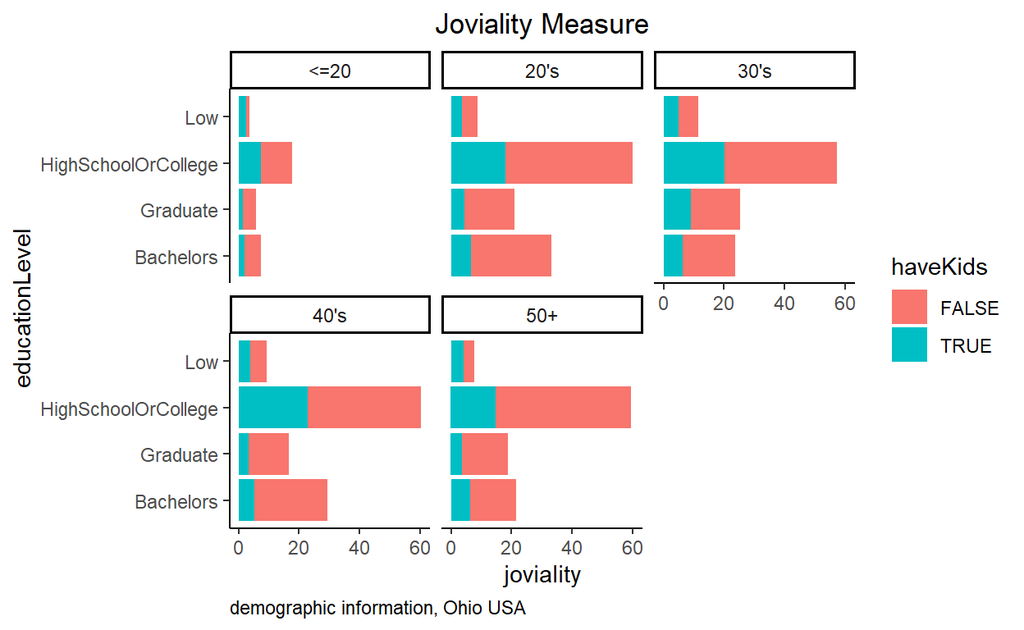

```r
ggplot(data=participants_data_mod,
       aes(x= joviality,
           y= educationLevel, fill = haveKids)) +
     geom_col() +
  theme_classic()+
 labs(
    title = "Joviality Measure",
    caption = "demographic information, Ohio USA"
  ) +
  theme(
    plot.title = element_text(hjust = 0.5),
    plot.subtitle = element_text(hjust = 1),
    plot.caption = element_text(hjust = 0)
  )+
  facet_wrap(~age_modified)
```

### Comments

Pros:

1. Segregation by facet grid allows reader to have a deeper appreciation of the data from different groups

Cons:

1. Addition of ‘haveKids’ adds too many dimensions to the data and may confuse the reader
2. Collectively depicting the Joviality of the various groups by using a bar chart is not accurate. A box plot should be used instead.
3. Mean statistic can be added to the boxplot
4. Ticks from the x axis can be removed
5. Axis can be renamed. Y axis can be re-orientated to make it more readable

### Revised Graph

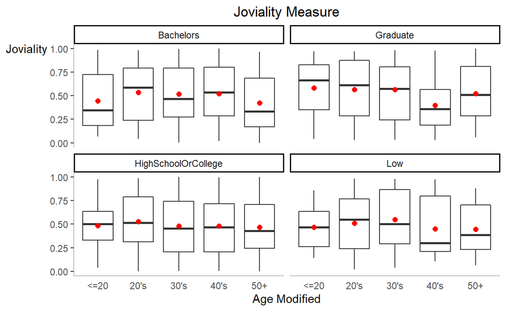

```r
ggplot(data=participants_data_mod,
       aes(x= age_modified,
           y= joviality)) +
     geom_boxplot() +
  stat_summary(geom = "point",
               fun="mean",
               colour="red",
               size=2) +
  theme_classic()+
 labs(
    title = "Joviality Measure", y="Joviality",
    x='Age Modified') +
  theme(axis.title.y= element_text(angle=0), axis.ticks.x= element_blank(),
    plot.title = element_text(hjust = 0.5),
    plot.subtitle = element_text(hjust = 1),
    plot.caption = element_text(hjust = 0),
    panel.background= element_blank(), axis.line= element_line(color= 'grey'))+
  facet_wrap(~educationLevel)
```

## Graph 4: Joviality Measure by Interest Group

### Original Graph

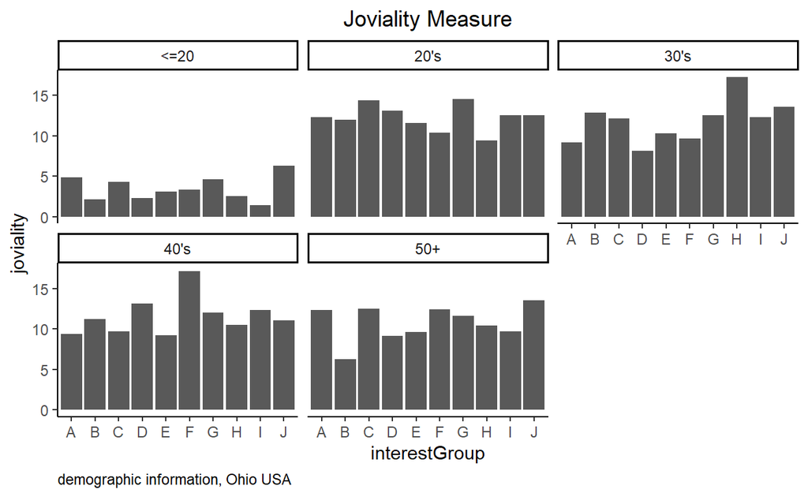

```r
ggplot(data=participants_data_mod,
       aes(x= interestGroup,
           y= joviality)) +
     geom_col() +
  theme_classic()+
 labs(
    title = "Joviality Measure",
    caption = "demographic information, Ohio USA"
  ) +
  theme(
    plot.title = element_text(hjust = 0.5),
    plot.subtitle = element_text(hjust = 1),
    plot.caption = element_text(hjust = 0)
  )+
  facet_wrap(~age_modified)
```

### Comments

Pros:

1. Segregation by facet grid allows reader to have a deeper appreciation of the data from different groups

Cons:

1. Collectively depicting the Joviality of the various groups by using a bar chart is not accurate. A box plot should be used instead.
2. Mean statistic can be added to the boxplot
3. Ticks from the x axis can be removed
4. Axis can be renamed. Y axis can be re-orientated to make it more readable

### Revised Graph

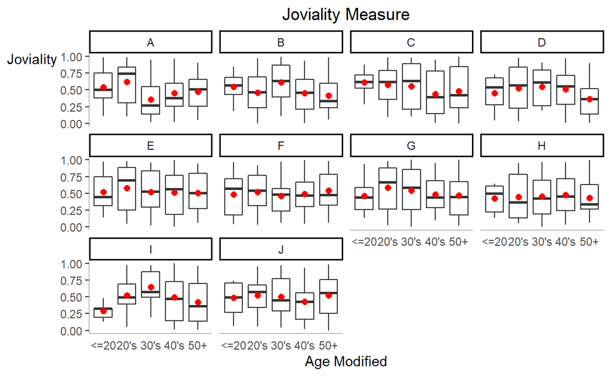

```r
ggplot(data=participants_data_mod,
       aes(x= age_modified,
           y= joviality)) +
     geom_boxplot() +
  stat_summary(geom = "point",
               fun="mean",
               colour="red",
               size=2) +
  theme_classic()+
 labs(
    title = "Joviality Measure", y="Joviality",
    x='Age Modified') +
  theme(axis.title.y= element_text(angle=0), axis.ticks.x= element_blank(),
    plot.title = element_text(hjust = 0.5),
    plot.subtitle = element_text(hjust = 1),
    plot.caption = element_text(hjust = 0),
    panel.background= element_blank(), axis.line= element_line(color= 'grey'))+
  facet_wrap(~interestGroup)
```